# Quiz 4 in Class

Shane Hauck

2/16/2022

Question 1 (20 points). Examine the alcohol.csv data set that you may have used as an introductory data set in STAT/DATA 234:

```r
library(tidyverse)
library(here)
alcohol_df <- read_csv(here("data/alcohol.csv"))
```

The data set has the following variables on countries throughout the world:

country, the name of the country beer_servings, the number of beer servings per person per year spirit_servings, the number of spirit servings per person per year wine_servings, the number of wine servings per person per year total_litres_of_pure_alcohol, the number of litres of pure alcohol consumed per person per year Construct a map of the beer_servings variable. You should choose an appropriate projection and change the default colour scheme of your map.

```r
world_df <- ggplot2::map_data("world")
world_full <- left_join(world_df, alcohol_df, by = c("region" = "country"))
```

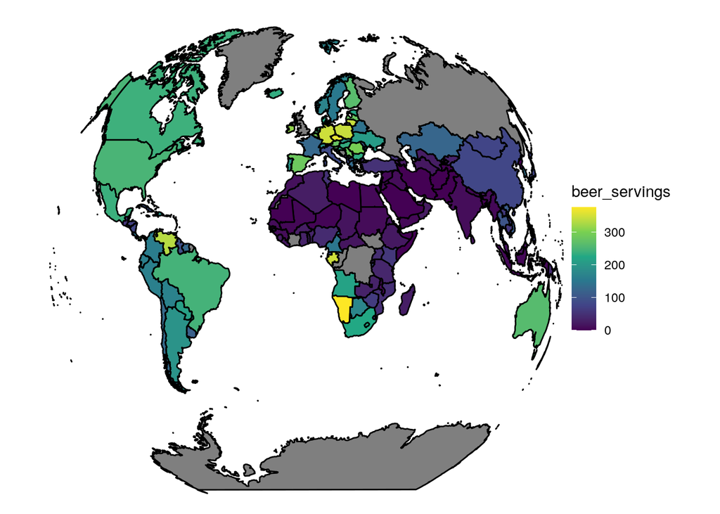

```r
ggplot(data = world_full,
            mapping = aes(x = long, y = lat,
                          group = group)) +
  geom_polygon(color = "black", aes(fill = beer_servings)) +
  theme_void() +
  coord_map(projection = "gilbert", xlim = c(-180, 180)) +
  scale_fill_viridis_c()
```

Question 2 (5 points). Give an example of a question of interest about the alcohol data where you would want to construct a visualization other than a map to answer the question. What type of visualization would you construct instead?

A question of interest about the alcohol data that you might want to construct a visualization other than a map could be something about looking at beer servings over time. To showcase the data over time you would likely want to use something the a line plot or scatter plot.